# Screeningsprogrammer

A-niveau

Bioteknologi

**Forudsætninger og tidsforbrug**

Forløbet kræver kendskab til:

- Deskriptiv statistik
- Normalfordelingen

**Tidsforbrug i matematik:** Ca. 3 x 90 minutter.

**Tidsforbrug i bioteknologi:** Ca. 4 x 90 minutter.

### Formål

Kan man lave screeningsprogrammer for sygdomme baseret på genetiske markører med brug af AI? Det undersøger vi i dette forløb, som med fordel kan foregå i et samarbejde med bioteknologi.

## Introduktion

Screeningsprogrammer anvendes, når sundhedsmyndighederne til en udvalgt befolkningsgruppe tilbyder en eller anden form for test for en specifik sygdom. Testen skal helst være forholdsvis billig og nem at udføre, så man kan teste mange mennesker. Screeningsprogrammer anvendes ofte i forbindelse med kræft. For eksempel tilbydes alle danske kvinder i bestemte aldersgrupper screening for livmoderhalskræft og for brystkræft. Tilsvarende bliver alle danskere i alderen fra 50 til 74 år screenet for tarmkræft.

Man kan arbejde med dette forløb enten i matematik alene eller i bioteknologi alene. Men det vil selvfølgelig være oplagt at lave et fælles forløb i en matematik-bioteknologi studieretning.

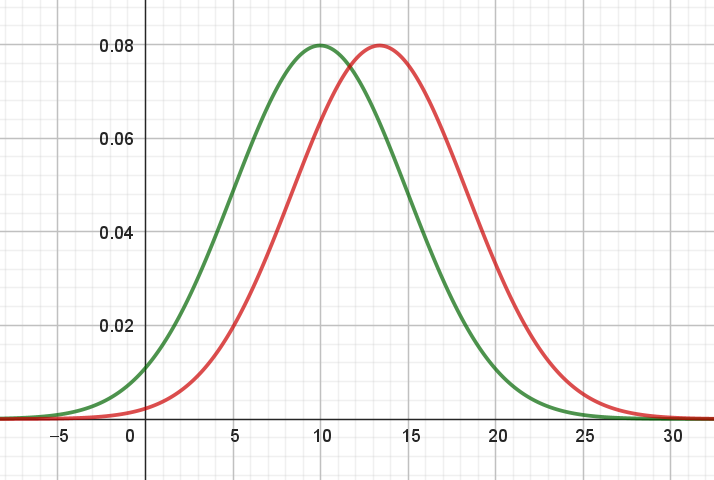

##### Screeningsprogrammer - matematik

[figure not shown]

##### Screeningsprogrammer - bioteknologi

Der tages udgangspunkt i afsnittet om kræft i Bioteknologi A - bind 3, men en tilsvarende bog om emnet kan selvfølgelig anvendes.